# Analyse Factorielle Multiple

L’analyse factorielle multiple (AFM) est une technique de traitement et de visualisation des données multidimensionnelles qui a pour objectif de réduire la dimensionnalité d’un ensemble de données tout en conservant le maximum d’informations. Elle est similaire à l’analyse en composantes principales (ACP), mais elle est plus flexible et permet de prendre en compte des hypothèses sur les relations entre les variables.

Comme pour l’ACP, l’AFM consiste à trouver de nouvelles variables, appelées “facteurs”, qui sont des combinaisons linéaires des variables originales. Ces facteurs sont choisis de sorte qu’ils expliquent le maximum de variance possible dans les données. Toutefois, contrairement à l’ACP, l’AFM permet de spécifier des hypothèses sur les relations entre les variables, par exemple en imposant que certains facteurs soient corrélés entre eux.

L’AFM est souvent utilisée lorsque l’on veut comprendre les relations de causalité entre les variables et lorsqu’on veut créer des indices composites à partir de plusieurs variables. Elle est également utilisée en prétraitement de données avant de les utiliser dans un modèle de prédiction ou de classification.

```r
library(tidyverse)  # Manipulation des données
library(readxl)     # Lecture des fichiers Excel
library(ggpubr)     # Représentations graphiques
library(rstatix)    # Tests statistiques en langage Dplyr
library(FactoMineR) # Analyses en composantes principales
library(factoextra) # Visualisation graphique de l'ACP
library(gtsummary)  # Résumé descriptif des données
library(corrplot)   # Corrélogrammes
library(plotly)     # Graphes intéractifs
```

# Avec les données complètes

```r
data <- read_excel("data/data_ubs.xlsx", sheet = "data_afm")
data$ID <- as.factor(data$ID)
data$Pays <- as.factor(data$Pays)
data$Poste <- as.factor(data$Poste)
data$Region <- as.factor(data$Region)
data$Experience <- as.factor(data$Experience)
data$Age <- as.factor(data$Age)
data$Sexe <- as.factor(data$Sexe)
data$Experience <- as.factor(data$Experience)
data$Type <- as.factor(data$Type)

data <- data %>%
  select(-C2, -C3, -C4.1,   -C4.2, -C4.3, -C4.4, -C4.5, -C4.6, -C4.7, -C4.8, -C4.9, -Type, -Pays)

data <- column_to_rownames(data, "ID")

dataComp <- data %>%
  drop_na()

dataComp
```

|  | Poste | Region | Experience | Age | Sexe | AFE1 | AFE2 | AFE4 | AFE5 | AFP1 | AFP2 | AFP3 | AFP4 | AFP5 | AFP6 | CF1 | CF2 | CF3 | CF4 | CF5 | CF6 | CF7 | CF8 | IEIP1 | IEIP2 | IEIP3 | IEIP4 | INTU1 | LDS1 | … |
| --- | --- | --- | --- | --- | --- | --- | --- | --- | --- | --- | --- | --- | --- | --- | --- | --- | --- | --- | --- | --- | --- | --- | --- | --- | --- | --- | --- | --- | --- | --- |
| FR7 | Armateur et patron-pecheur | Normandie | Plus de 20 ans | 45-54 | Homme | 3 | 2 | 4 | 3 | 3 | 2 | 5 | 5 | 5 | 3 | 5 | 1 | 5 | 5 | 5 | 4 | 4 | 4 | 5 | 3 | 3 | 2 | 5 | 2 | … |
| FR9 | Armateur et patron-pecheur | Normandie | Plus de 20 ans | 55-64 | Homme | 4 | 2 | 5 | 2 | 4 | 5 | 3 | 4 | 2 | 3 | 4 | 2 | 5 | 4 | 4 | 3 | 4 | 4 | 5 | 4 | 2 | 4 | 4 | 2 | … |
| FR10 | Matelot | Bretagne | Entre 10 et 15 ans | 25-34 | Homme | 4 | 3 | 4 | 2 | 3 | 4 | 5 | 4 | 4 | 4 | 4 | 4 | 4 | 5 | 4 | 4 | 4 | 4 | 4 | 4 | 4 | 3 | 4 | 2 | … |
| FR16 | Patron-pecheur | Haut de France | Plus de 20 ans | 45-54 | Homme | 4 | 2 | 5 | 2 | 4 | 5 | 5 | 5 | 5 | 4 | 5 | 2 | 4 | 5 | 4 | 5 | 2 | 3 | 4 | 4 | 4 | 2 | 4 | 2 | … |
| FR17 | Armateur et patron-pecheur | Autre | Entre 15 et 20 ans | 55-64 | Homme | 4 | 4 | 5 | 5 | 4 | 3 | 4 | 5 | 5 | 4 | 5 | 5 | 4 | 5 | 5 | 3 | 5 | 5 | 5 | 5 | 5 | 1 | 4 | 2 | … |
| FR19 | Patron-pecheur | Bretagne | Plus de 20 ans | 55-64 | Homme | 5 | 2 | 4 | 4 | 3 | 3 | 4 | 5 | 5 | 3 | 2 | 3 | 5 | 5 | 5 | 5 | 4 | 4 | 4 | 5 | 5 | 4 | 4 | 1 | … |
| FR20 | Armateur et patron-pecheur | Bretagne | Entre 15 et 20 ans | 25-34 | Homme | 4 | 5 | 4 | 2 | 4 | 3 | 4 | 4 | 4 | 4 | 4 | 2 | 3 | 4 | 4 | 2 | 3 | 4 | 4 | 4 | 4 | 4 | 4 | 1 | … |
| FR25 | Autres | Haut de France | Plus de 20 ans | 35-44 | Homme | 4 | 1 | 3 | 2 | 5 | 4 | 4 | 5 | 5 | 4 | 5 | 2 | 2 | 5 | 4 | 3 | 4 | 2 | 4 | 5 | 4 | 5 | 3 | 2 | … |
| FR27 | Armateur et patron-pecheur | Bretagne | Entre 10 et 15 ans | 35-44 | Homme | 3 | 3 | 1 | 2 | 3 | 3 | 3 | 5 | 5 | 3 | 4 | 2 | 3 | 5 | 4 | 5 | 3 | 3 | 4 | 4 | 4 | 4 | 3 | 2 | … |
| FR28 | Patron-pecheur | Autre | Entre 10 et 15 ans | 18-24 | Homme | 3 | 3 | 4 | 3 | 2 | 2 | 4 | 3 | 4 | 3 | 4 | 3 | 4 | 5 | 5 | 3 | 4 | 4 | 5 | 4 | 3 | 5 | 4 | 1 | … |

[output cut: 122 more lines]

```r
res.mfa <- MFA(dataComp,
               group = c(1, 1, 1, 1, 1, 4, 6, 8, 4, 1, 6, 9, 5),
               type = c("n", "n", "n", "n", "n", "s", "s", "s", "s", "s", "s", "s", "s"),
               name.group = c("Poste", "Region", "Experience", "Age", "Sexe", "AFE", "AFP", "CF", "IEIP", "INTU", "LDS", "MOT", "NSUB"),
               graph = F
               )

print(res.mfa)
```

```
**Results of the Multiple Factor Analysis (MFA)**
The analysis was performed on 132 individuals, described by 48 variables
*Results are available in the following objects :

   name                 description
1  "$eig"               "eigenvalues"
2  "$separate.analyses" "separate analyses for each group of variables"
3  "$group"             "results for all the groups"
4  "$partial.axes"      "results for the partial axes"
5  "$inertia.ratio"     "inertia ratio"
6  "$ind"               "results for the individuals"
7  "$quanti.var"        "results for the quantitative variables"
8  "$quali.var"         "results for the categorical variables"
9  "$summary.quanti"    "summary for the quantitative variables"
10 "$summary.quali"     "summary for the categorical variables"
11 "$global.pca"        "results for the global PCA"
```

## Valeurs propres

La valeur propre est une mesure de l’importance d’un facteur. Elle correspond au rapport entre la variance expliquée par le facteur et la variance totale des données. Plus la valeur propre d’un facteur est élevée, plus le facteur explique de variance dans les données et donc plus il est important.

Les valeurs propres sont généralement présentées sous forme de pourcentage, de manière à ce qu’elles puissent être comparées entre elles. Par exemple, si le premier facteur explique 40% de la variance totale des données et que le second facteur explique 20% de la variance, on peut dire que le premier facteur est deux fois plus important que le second.

```r
eig.val <- get_eigenvalue(res.mfa)
head(eig.val, 20)
```

```
       eigenvalue variance.percent cumulative.variance.percent
Dim.1   4.3197519        11.205060                    11.20506
Dim.2   2.6295689         6.820873                    18.02593
Dim.3   2.0969292         5.439252                    23.46518
Dim.4   1.7444788         4.525026                    27.99021
Dim.5   1.6380742         4.249022                    32.23923
Dim.6   1.5868503         4.116151                    36.35538
Dim.7   1.4868943         3.856874                    40.21226
Dim.8   1.4260020         3.698925                    43.91118
Dim.9   1.2828909         3.327707                    47.23889
Dim.10  1.2386956         3.213069                    50.45196
Dim.11  1.1359401         2.946530                    53.39849
Dim.12  1.1220236         2.910431                    56.30892
Dim.13  1.0434215         2.706544                    59.01546
Dim.14  0.9674557         2.509496                    61.52496
Dim.15  0.9160426         2.376135                    63.90109
Dim.16  0.8506358         2.206475                    66.10757
Dim.17  0.8350419         2.166026                    68.27360
Dim.18  0.8195805         2.125920                    70.39952
Dim.19  0.7327657         1.900730                    72.30025
Dim.20  0.6585661         1.708263                    74.00851
```

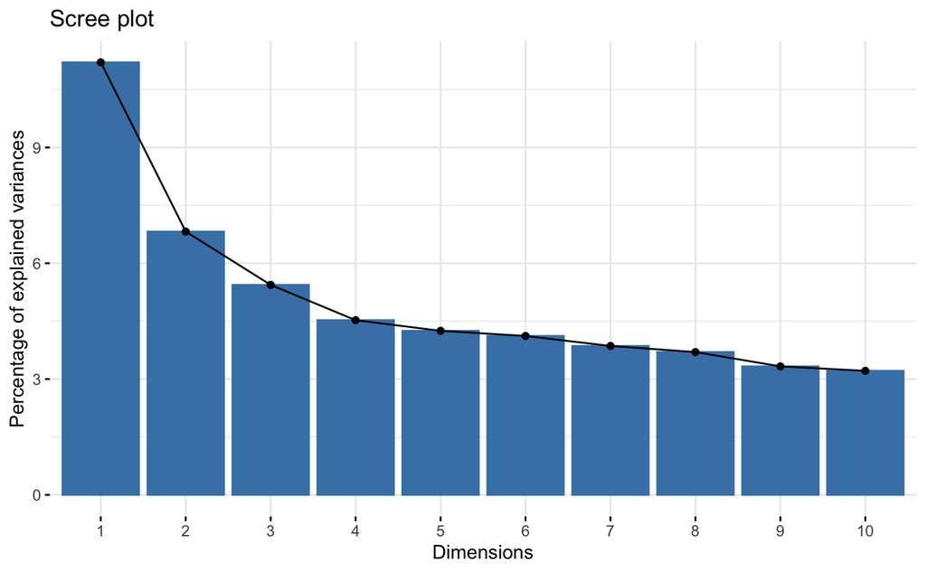

```r
fviz_screeplot(res.mfa)
```

## Contribution aux dimensions

```r
group <- get_mfa_var(res.mfa, "group")
group
```

```
Multiple Factor Analysis results for variable groups
 ===================================================
  Name           Description
1 "$coord"       "Coordinates"
2 "$cos2"        "Cos2, quality of representation"
3 "$contrib"     "Contributions"
4 "$correlation" "Correlation between groups and principal dimensions"
```

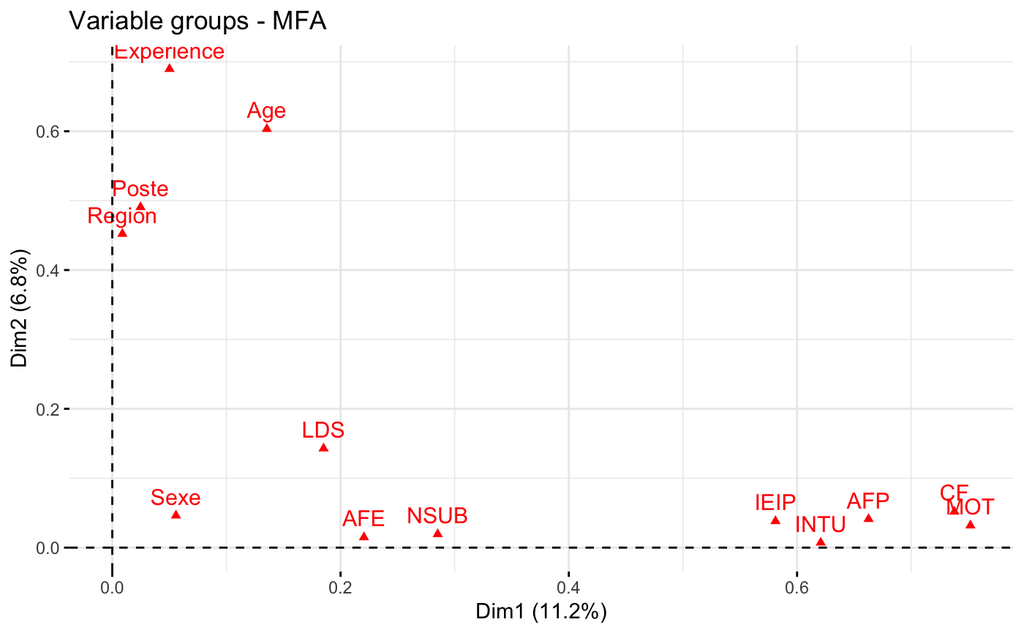

```r
fviz_mfa_var(res.mfa, "group")
```

Le graphique ci-dessus illustre la corrélation entre les groupes et les dimensions.

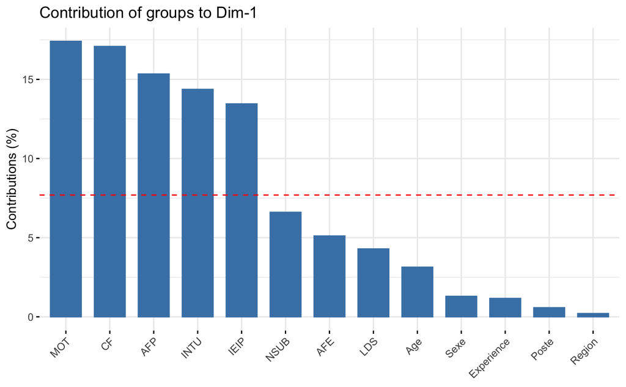

```r
# Contribution à la première dimension
fviz_contrib(res.mfa, "group", axes = 1)
```

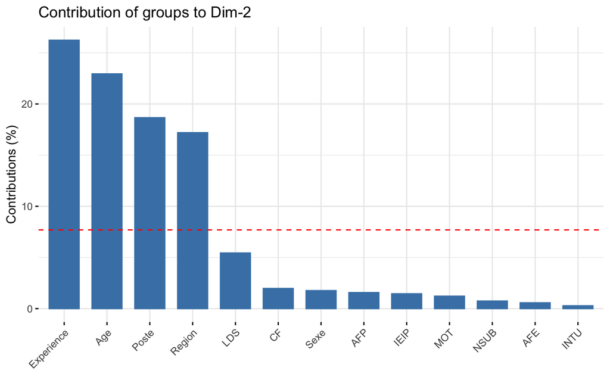

```r
# Contribution à la deuxième dimension
fviz_contrib(res.mfa, "group", axes = 2)
```

### Variables quantitatives

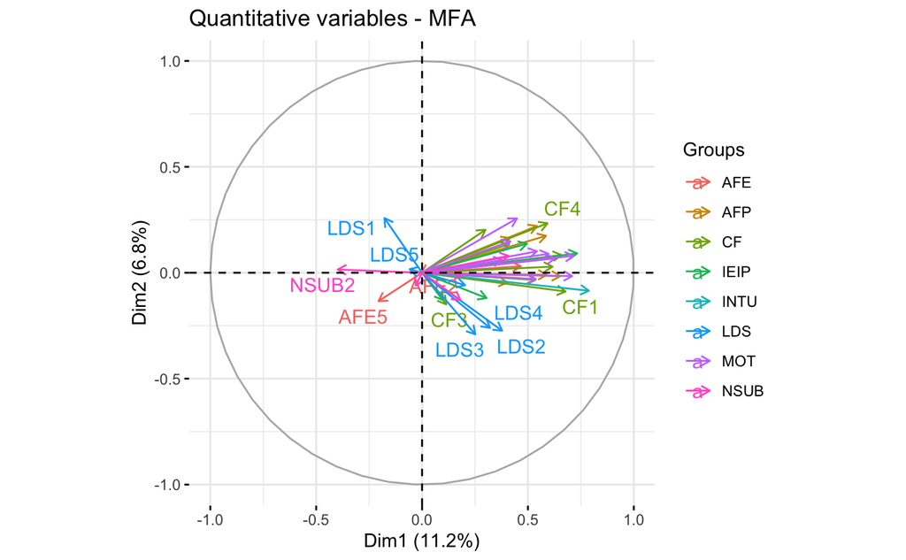

```r
quanti.var <- get_mfa_var(res.mfa, "quanti.var")

fviz_mfa_var(res.mfa, "quanti.var", repel = T)
```

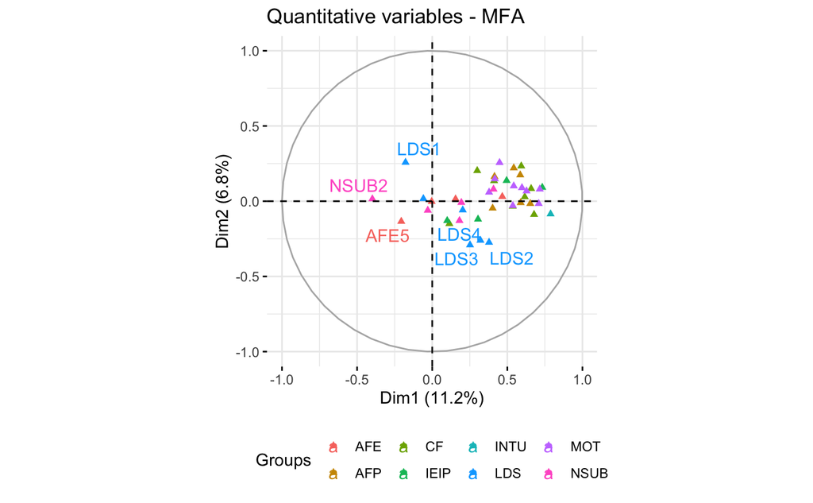

```r
fviz_mfa_var(res.mfa, "quanti.var", repel = T, geom = c("point", "text"), legend = "bottom")
```

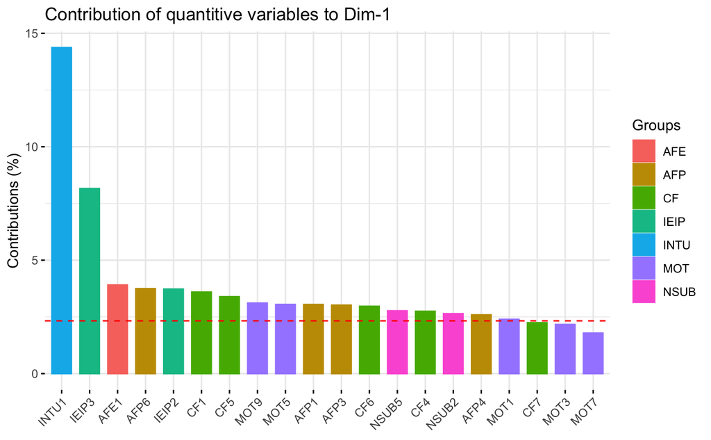

```r
fviz_contrib (res.mfa, choice = "quanti.var", axes = 1, top = 20)
```

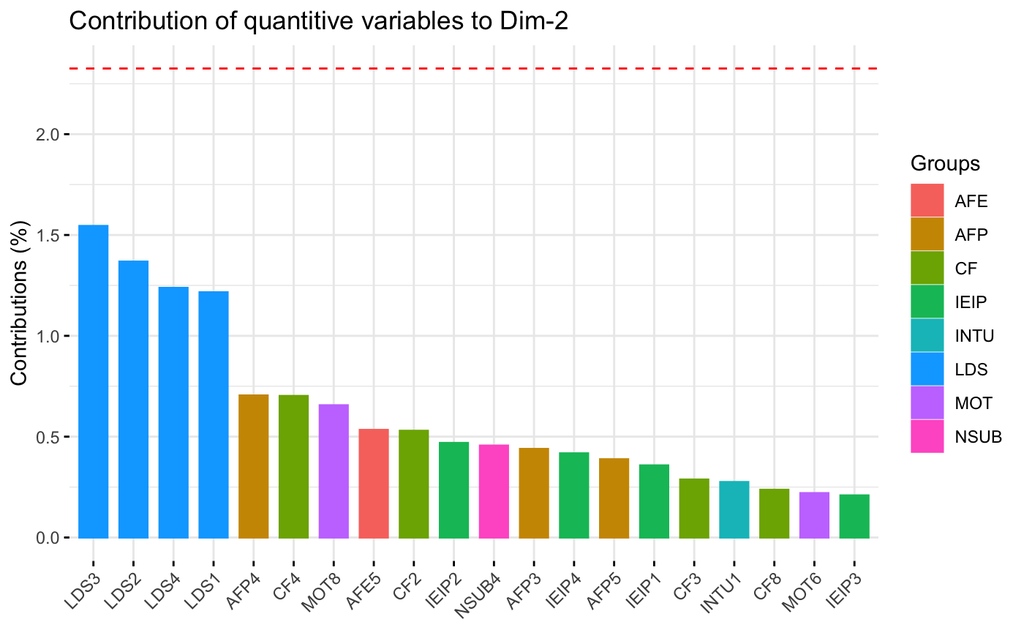

```r
fviz_contrib (res.mfa, choice = "quanti.var", axes = 2, top = 20)
```

## Individus

### Contribution

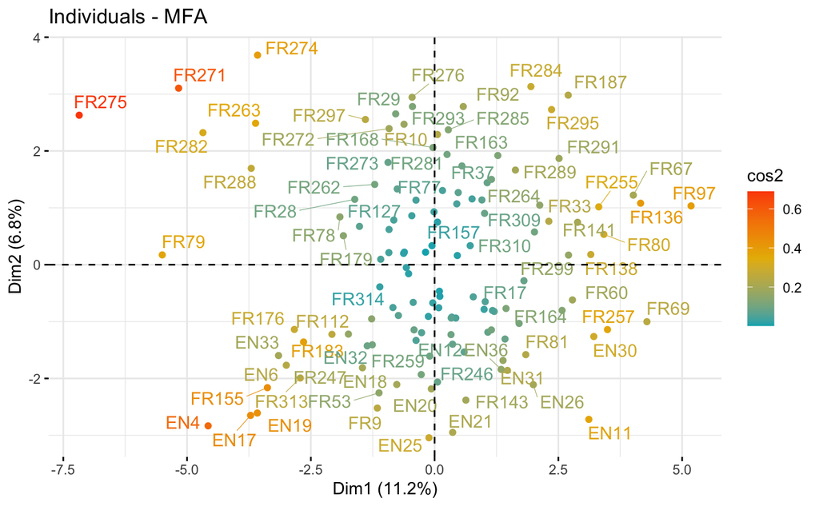

```r
ind <- get_mfa_ind(res.mfa)

fviz_mfa_ind(res.mfa, col.ind = "cos2",
             gradient.cols = c("#00AFBB", "#E7B800", "#FC4E07"),
             repel = T)
```

### Sexe

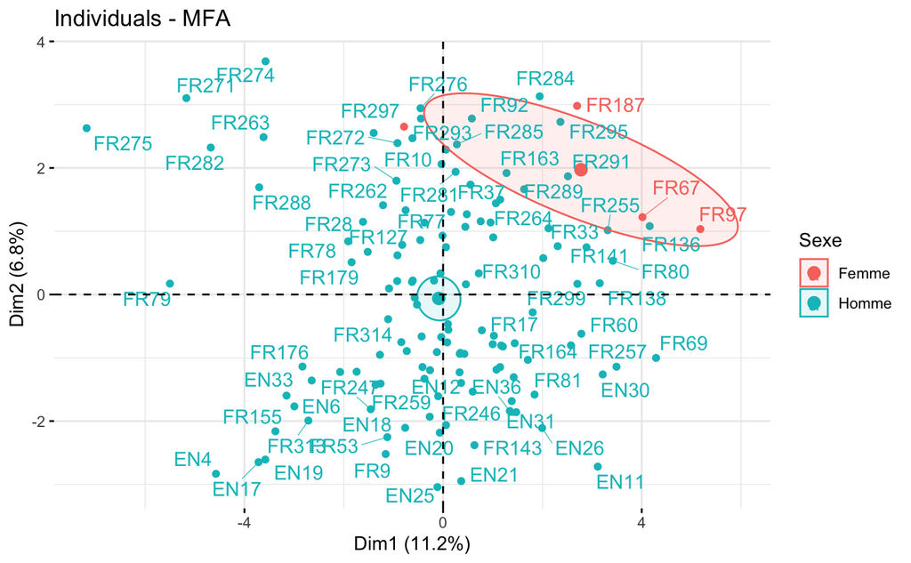

```r
fviz_mfa_ind(res.mfa,
             habillage = "Sexe", # color by groups
             addEllipses = TRUE, ellipse.type = "confidence",
             repel = TRUE
             )
```

### Poste

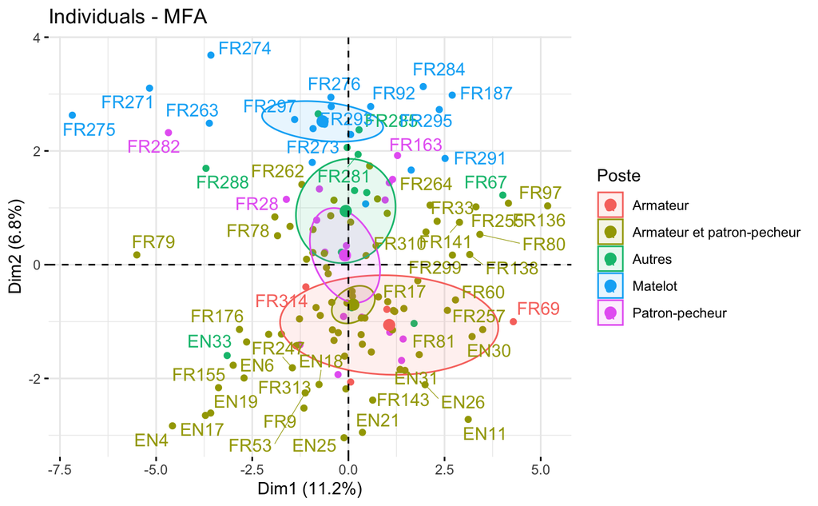

```r
fviz_mfa_ind(res.mfa,
             habillage = "Poste", # color by groups
             addEllipses = TRUE, ellipse.type = "confidence",
             repel = TRUE
             )
```

### Région

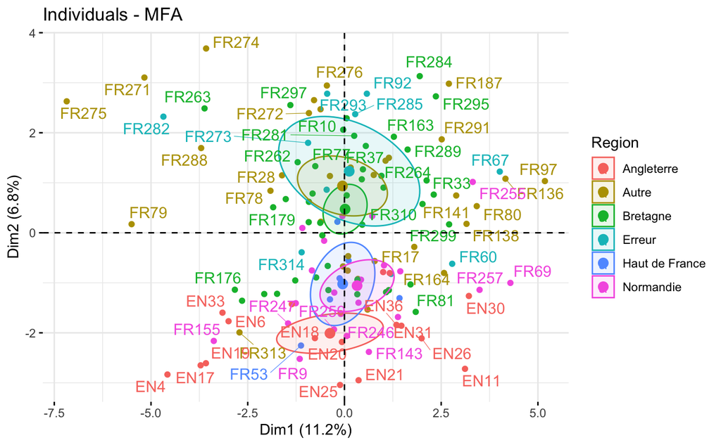

```r
fviz_mfa_ind(res.mfa,
             habillage = "Region", # color by groups
             addEllipses = TRUE, ellipse.type = "confidence",
             repel = TRUE
             )
```

### Expérience

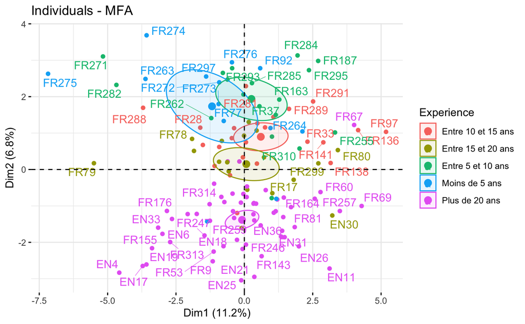

```r
fviz_mfa_ind(res.mfa,
             habillage = "Experience", # color by groups
             addEllipses = TRUE, ellipse.type = "confidence",
             repel = TRUE
             )
```

### Age

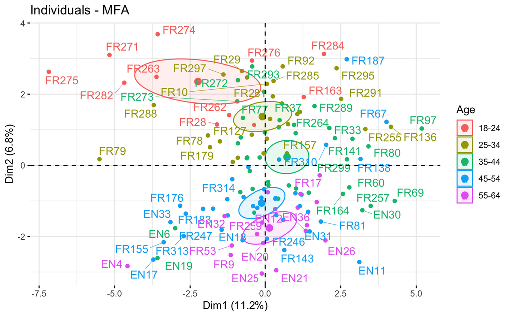

```r
fviz_mfa_ind(res.mfa,
             habillage = "Age", # color by groups
             addEllipses = TRUE, ellipse.type = "confidence",
             repel = TRUE
             )
```